# Time Series Analysis and Its Applications - Exercises

Ewok

June 6, 2016

# Chapter 1

### Brain Activation Plots

The following plots show measures of activation in the brain in terms of blood oxygenation-level dependent signal intensity for five subjects when given periodic brushing on the hand. The signal period is 64 seconds, and the sampling rate is one observation every 2 seconds for 256 seconds. The results were averaged over subjects.

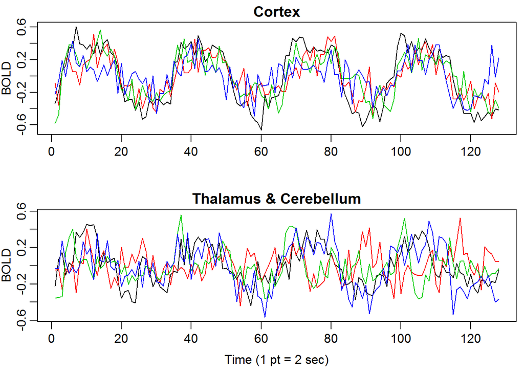

```r
par(mfrow=c(2,1), mar=c(3,2,1,0)+.5, mgp=c(1.6,.6,0))
ts.plot(fmri1[,2:5], col=1:4, ylab="BOLD", xlab="", main="Cortex")
ts.plot(fmri1[,6:9], col=1:4, ylab="BOLD", xlab="", main="Thalamus & Cerebellum")
mtext("Time (1 pt = 2 sec)", side=1, line=2)
```

### Effect of White Noise

The next plots show the effect of increasing additive white Gaussian noise to a cosine wave.

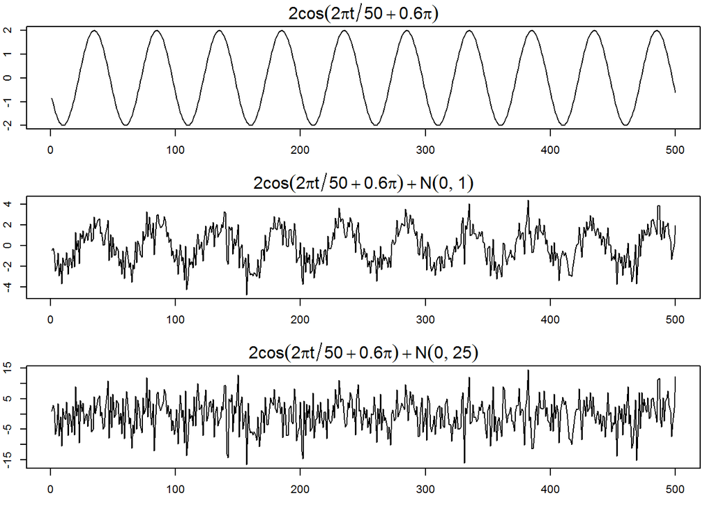

```r
cs = 2*cos(2*pi*1:500/50 + .6*pi); w = rnorm(500,0,1)
par(mfrow=c(3,1), mar=c(3,2,2,1), cex.main=1.5)
plot.ts(cs, main=expression(2*cos(2*pi*t/50+.6*pi)))
plot.ts(cs+w, main=expression(2*cos(2*pi*t/50+.6*pi) + N(0,1)))
plot.ts(cs+5*w, main=expression(2*cos(2*pi*t/50+.6*pi) + N(0,25)))
```

# Chapter 2

### Mortality, Temperature, and Pollution

The following plots show average weekly cardiovascular mortality, temperature, and particulate pollution in Los Angeles County over a 10 year period from 1970 to 1979.

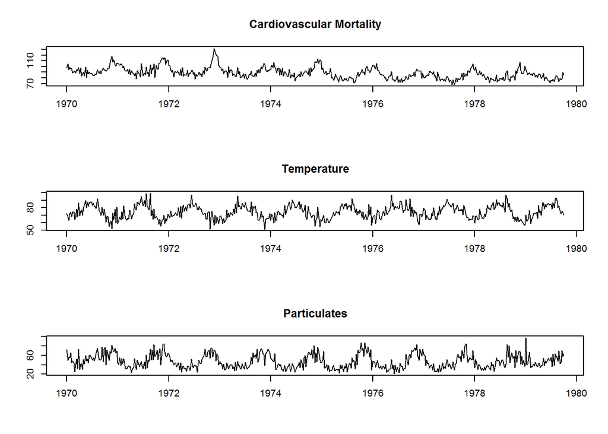

```r
par(mfrow=c(3,1)) # plot the data
plot(cmort, main="Cardiovascular Mortality", xlab="", ylab="")
plot(tempr, main="Temperature", xlab="", ylab="")
plot(part, main="Particulates", xlab="", ylab="")
```

The data is then plotted on a scatterplot matrix to visualize the relations between the three variables. Temperature, which is negatively correlated with mortality, appears to have a quadratic effect on it. Pollution is positivily correlated with mortality.

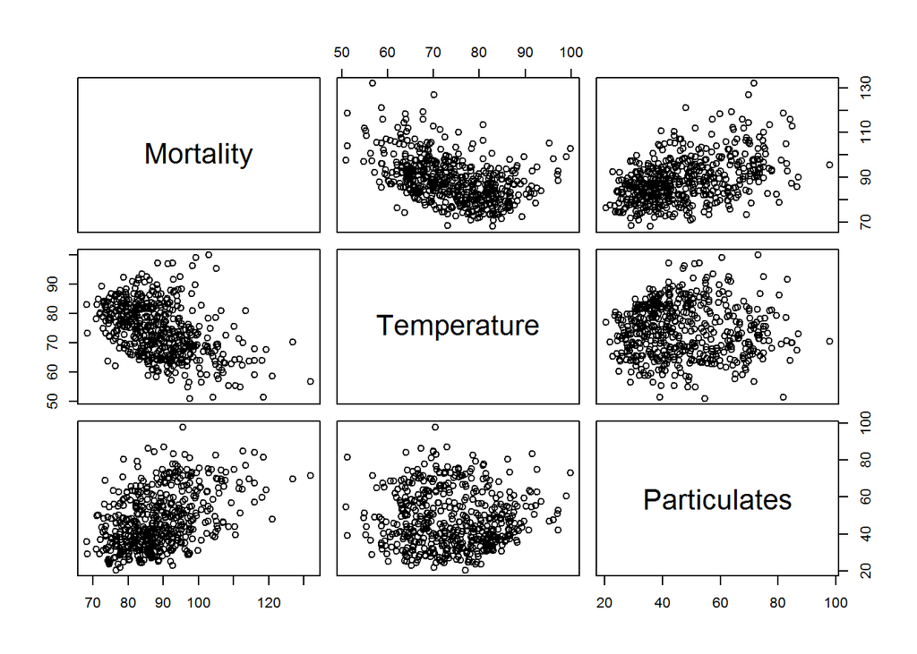

```r
pairs(cbind(Mortality=cmort, Temperature=tempr, Particulates=part))
```

### Smoothing a Time Series

The following shows four different methods to smooth a time series in order to remove white noise. The moving average plot uses the average of the six previous and six future data points. The kernel smoother is a weighted moving average smoother, giving more weight to data points that are closer to the point being estimated. The locally weighted scatterplot smoother (lowess) uses nearest neighbor regression to smooth the plot. Finally, the smoothed spline plot uses polynomial regression to estimate each point.

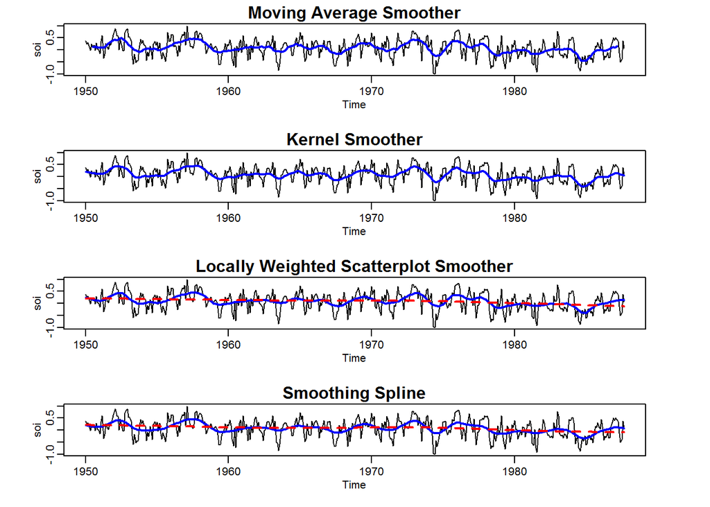

```r
par(mfrow=c(4,1), mar=c(3,4,1,4)+.8, mgp=c(1.6,.6,0), cex.main=1.5)
wgts = c(.5, rep(1,11), .5)/12
soif = filter(soi, sides=2, filter=wgts)
plot(soi, main="Moving Average Smoother")
lines(soif, lwd=2, col=4)
plot(soi, main="Kernel Smoother")
lines(ksmooth(time(soi), soi, "normal", bandwidth=1), lwd=2, col=4)
plot(soi, main="Locally Weighted Scatterplot Smoother")
lines(lowess(soi, f=.05), lwd=2, col=4)
lines(lowess(soi), lty=2, lwd=2, col=2)
plot(soi, main="Smoothing Spline")
lines(smooth.spline(time(soi), soi, spar=.5), lwd=2, col=4)
lines(smooth.spline(time(soi), soi, spar=1), lty=2, lwd=2, col=2)
```

# Chapter 3

### Forecasting and Backcasting

The following figure shows the result of forecasting the Recruitment series (the number of new fish in the Pacific over a 453 month period). The forecasts are calculated utilizing this equation:
$$x^{n}_{n+m} = 6.74 + 1.35x^{n}_{n+m-1} - .46x^{n}_{n+m-2}$$
where n = 453 and m = 1, 2, …, 24. The forecast is shown with plus and minus one standard deviation. It can be seen that the prediction intervals are wide and the forecast levels off quickly.

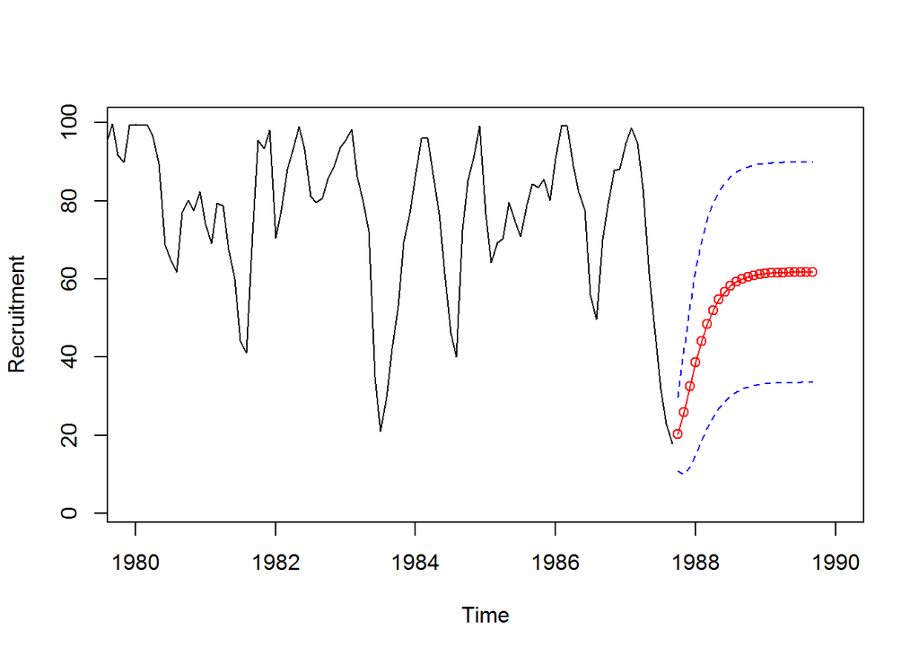

```r
regr = ar.ols(rec, order=2, demean=FALSE, intercept=TRUE)
fore = predict(regr, n.ahead=24)
ts.plot(rec, fore$pred, col=1:2, xlim=c(1980,1990), ylab="Recruitment")
lines(fore$pred, type="p", col=2)
lines(fore$pred+fore$se, lty="dashed", col=4)
lines(fore$pred-fore$se, lty="dashed", col=4)
```

Just as we can forecast a forward model, we can backcast a backward model. To do so, simply truncate the last error to zero and then iterate backward (generating the errors backward). Then plug this back into the new ARMA model. In R, we can backcast by reversing the data and then fitting the model and predicting as we would normally. The figure below shows an example.

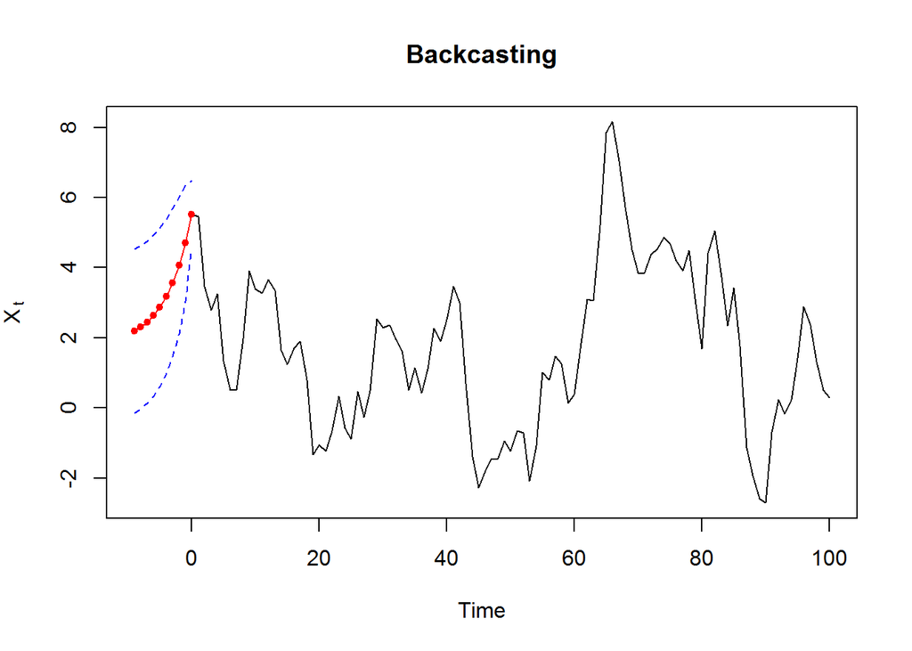

```r
set.seed(90210)
x = arima.sim(list(order = c(1,0,1), ar =.9, ma=.5), n = 100)
xr = replace(x, TRUE, rev(x)) # xr is the reversed data
pxr = predict(arima(xr, order=c(1,0,1)), 10) # predict the reversed data
pxrp = rev(pxr$pred) # reorder the predictors (for plotting)
pxrse = rev(pxr$se) # reorder the SEs
nx = ts(c(pxrp, x), start=-9) # attach the backcasts to the data
plot(nx, ylab=expression(X[~t]), main='Backcasting')
lines(-9:0, nx[1:10], col=2, type='o', pch=20)
lines(-9:0, nx[1:10] + pxrse, col=4, lty=2)
lines(-9:0, nx[1:10] - pxrse, col=4, lty=2)
```

### Seasonal ARIMA Models

The next analysis looks at the data set AirPassengers, which are the monthly totals of international airline passengers from 1949 to 1960. We achieve a twelve month forecast using the $ARIMA(0,1,1) \times (0,1,1)_{12}$ model on the logged data set. The SARIMA model accounts for trends both within and between the seasons. A table of predicted values and standard errors appears below the graph.

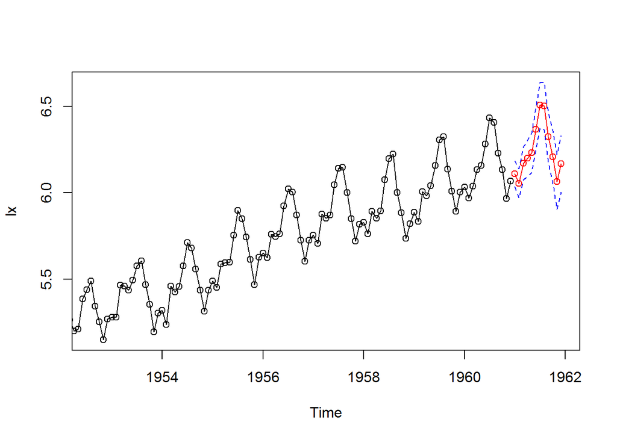

```
## $pred
##           Jan      Feb      Mar      Apr      May      Jun      Jul
## 1961 6.110186 6.053775 6.171715 6.199300 6.232556 6.368779 6.507294
##           Aug      Sep      Oct      Nov      Dec
## 1961 6.502906 6.324698 6.209008 6.063487 6.168025
##
## $se
##             Jan        Feb        Mar        Apr        May        Jun
## 1961 0.03671562 0.04278291 0.04809072 0.05286830 0.05724856 0.06131670
##             Jul        Aug        Sep        Oct        Nov        Dec
## 1961 0.06513124 0.06873441 0.07215787 0.07542612 0.07855851 0.08157070
```

```r
x = AirPassengers
lx = log(x)
sarima.for(lx, 12, 0,1,1, 0,1,1,12)
```

# Chapter 4

### Summing Periodic Series

An alternative to the time domain approach to time series analysis is the frequency domain approach, in which series are expressed as linear combinations of sine and cosine functions. The following set of graphs shows three different equations along with their sum, displaying how different sine/cosine functions can be summed to produce more complicated periodic functions.

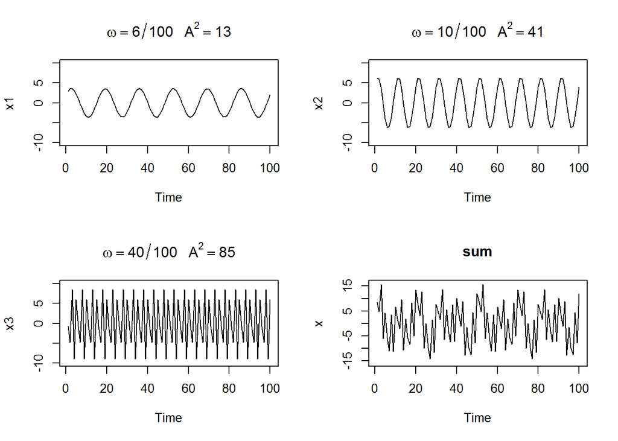

```r
x1 = 2*cos(2*pi*1:100*6/100) + 3*sin(2*pi*1:100*6/100)
x2 = 4*cos(2*pi*1:100*10/100) + 5*sin(2*pi*1:100*10/100)
x3 = 6*cos(2*pi*1:100*40/100) + 7*sin(2*pi*1:100*40/100)
x = x1 + x2 + x3
par(mfrow=c(2,2))
plot.ts(x1, ylim=c(-10,10), main=expression(omega==6/100~~~A^2==13))
plot.ts(x2, ylim=c(-10,10), main=expression(omega==10/100~~~A^2==41))
plot.ts(x3, ylim=c(-10,10), main=expression(omega==40/100~~~A^2==85))
plot.ts(x, ylim=c(-16,16), main="sum")
```

From this summed periodic function, we can then use Fourier analysis to achieve the underlying frequencies. The following figure is a scaled periodogram which shows the components of the time series.

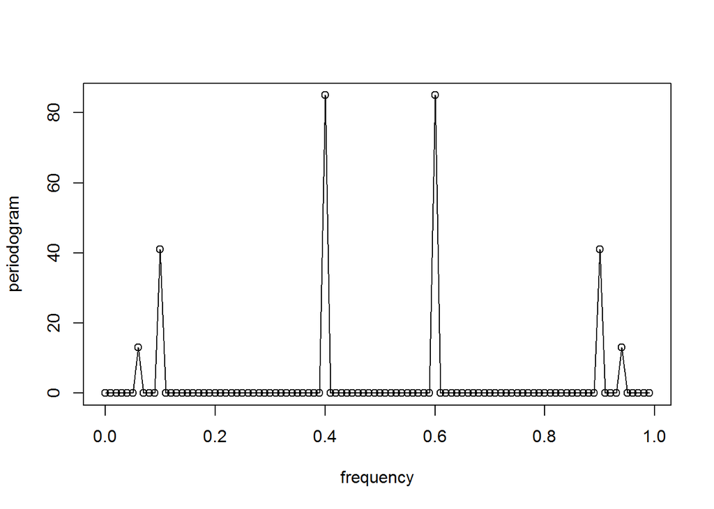

```r
P = Mod(2*fft(x)/100)^2
Fr = 0:99/100
plot(Fr, P, type="o", xlab="frequency", ylab="periodogram")
```

Note that there is a mirroring effect at the folding frequency of 1/2. The folding frequency is the highest frequency that can be seen by discrete sampling. Typically, a periodogram is not plotted past the folding frequency. The decomposition of a periodic function into its component frequencies is known as spectral analysis.

### Linear Filters

Linear filters modify the spectral characteristics of time series in a predictable way, and they can be used for extracting certain signals from the time series. Two basic kinds of linear filters are the first difference and moving average filters, given by the following two equations respectively.
$$y_{t} = \nabla x_{t} = x_{t} - x_{t-1}$$
$$y_{t} = \frac{1}{24}(x_{t-6} + x_{t+6}) + \frac{1}{12} \sum_{r=-5}^5 x_{t-r}$$

Here the filters are shown as applied to the SOI series.

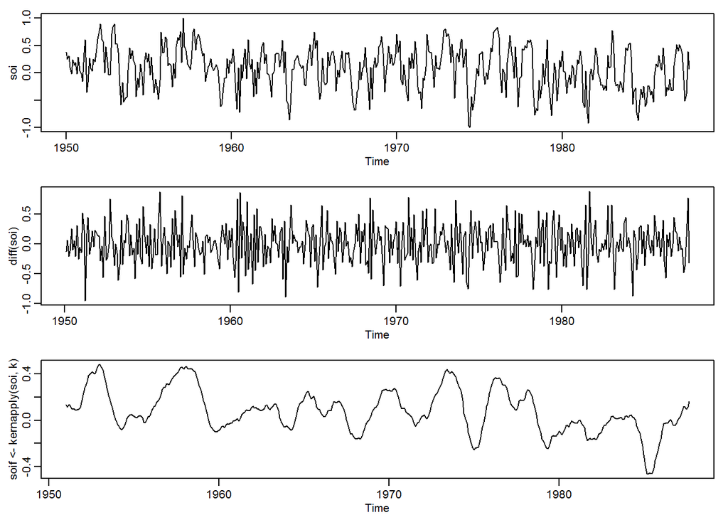

```r
par(mfrow=c(3,1), mar=c(3,3,1,1), mgp=c(1.6,.6,0))
plot(soi) # plot data
plot(diff(soi)) # plot first difference
k = kernel("modified.daniell", 6) # filter weights
plot(soif <- kernapply(soi, k)) # plot 12 month filter
```

Differencing is an example of a high-pass filter because it retains (or passes) the higher frequencies, while the moving average is an example of a low-pass filter because it passes the lower frequencies. The following graph shows the squared frequency response functions of the first difference and moving average filters.

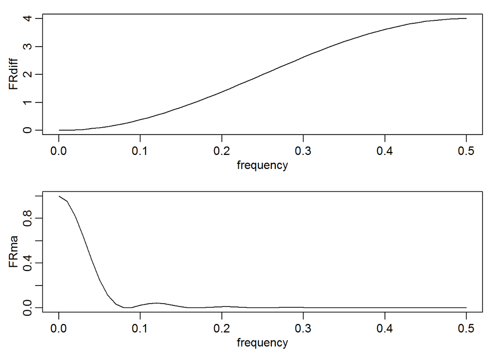

```r
par(mfrow=c(2,1), mar=c(3,3,1,1), mgp=c(1.6,.6,0))
w = seq(0, .5, by=.01)
FRdiff = abs(1-exp(2i*pi*w))^2
plot(w, FRdiff, type='l', xlab='frequency')
u = cos(2*pi*w)+cos(4*pi*w)+cos(6*pi*w)+cos(8*pi*w)+cos(10*pi*w)
FRma = ((1 + cos(12*pi*w) + 2*u)/12)^2
plot(w, FRma, type='l', xlab='frequency')
```

# Chapter 5

### Threshold Models

Threshold models are used to distinguish ranges of values where the predicted behavior of the model can vary. In this case we look at monthly pneumonia and influenza deaths per 10,000 people in the US from 1968 to 1978. We can see that there is a slight negative trend along with large bursts of positive and negative changes that periodically occur. The peaks of the seasonal ranges are often in January, but not always.

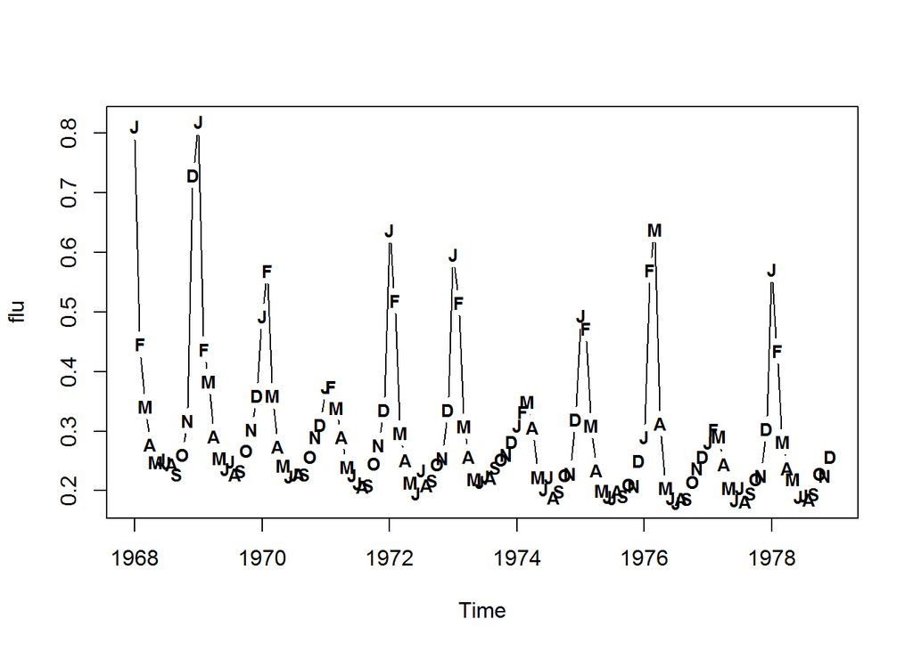

```r
plot(flu, type="c")
Months = c("J","F","M","A","M","J","J","A","S","O","N","D")
points(flu, pch=Months, cex=.8, font=2)
```

Here we use threshold modeling to make predictions.

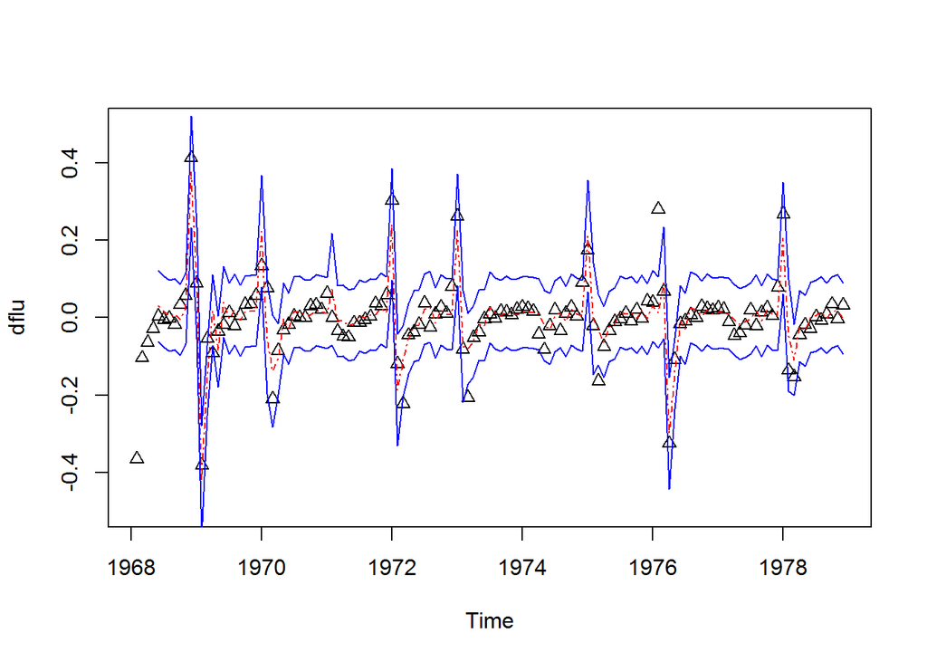

```r
dflu = diff(flu)
thrsh = .05 # threshold
Z = ts.intersect(dflu, lag(dflu,-1), lag(dflu,-2), lag(dflu,-3),
lag(dflu,-4))
ind1 = ifelse(Z[,2] < thrsh, 1, NA) # indicator < thrsh
ind2 = ifelse(Z[,2] < thrsh, NA, 1) # indicator >= thrsh
X1 = Z[,1]*ind1
X2 = Z[,1]*ind2
fit1<-lm(X1~Z[,2:5]) # case 1
fit2<-lm(X2~Z[,2:5]) # case 2
D = cbind(rep(1, nrow(Z)), Z[,2:5]) # get predictions
b1 = fit1$coef
b2 = fit2$coef
p1 = D%*%b1
p2 = D%*%b2
prd = ifelse(Z[,2] < thrsh, p1, p2)
plot(dflu, type="p", pch=2, ylim=c(-.5,.5))
lines(prd, lty=4, col=2)
prde1 = sqrt(sum(resid(fit1)^2)/df.residual(fit1))
prde2 = sqrt(sum(resid(fit2)^2)/df.residual(fit2))
prde = ifelse(Z[,2] < thrsh, prde1, prde2)
lines(prd + 2*prde, col=4)
lines(prd - 2*prde, col=4)
```

The graph shows the first differenced US monthly pneumonia and influenza deaths (traingles), one-month-ahead predictions (dashed red line) and $\pm2$ prediction error bounds (solid blue lines).